# Lauren_Anikis_Final_Markdown

```r
#install.packages("janitor")
#install.packages("arcos")
#install.packages("tidycensus")
#install.packages("mapview")
#install.packages("ggthemes")
#install.packages("scales")
#install.packages("tidyverse")
#install.packages("ggrepel")
library(janitor)
library(arcos)
library(tidyverse)
library(tidycensus)
library(mapview)
library(ggthemes)
library(scales)
library(ggrepel)
```

```r
key <- "uO4EK6I"
arcos_county_pills_per_year <- summarized_county_annual(key = key) %>%
  clean_names()
arcos_county_population_per_year <- county_population(key = key) %>%
  clean_names()
```

#Pull in data This is the data for overdoses, RUCC, and unemployment

```r
overdoses_data <- read_tsv("data/2006-2012.tsv")
urban_rural_continuum <- read_csv("data/ruralurbancodes2013.csv")
unemployment_data <- read_csv("data/county_unemployment.csv")
```

Here I need to clean up the overdoses data as there is a lot of missing, suppressed, or unreliable data.

```r
overdoses_data <- overdoses_data %>%
  filter(!str_detect(`Crude Rate`, "Missing|Suppressed|Unreliable")) %>%
  mutate(`Crude Rate` = as.numeric(`Crude Rate`))
```

```r
overdose_urban_rural_combined <- overdoses_data %>%
  inner_join(urban_rural_continuum, by=c("County Code" = "FIPS"))
```

#Pull in ARCOS data

```r
arcos_county_pills_and_population <- arcos_county_pills_per_year %>%
  inner_join(arcos_county_population_per_year, by=c("countyfips", "buyer_county", "buyer_state", "year")) %>%
  group_by(countyfips, buyer_county, buyer_state) %>%
  summarise(total_pills = sum(dosage_unit), total_population = sum(population)) %>%
  mutate(pills_per_person = total_pills/total_population) %>%
  inner_join(urban_rural_continuum, by=c("countyfips" = "FIPS"))

arcos_county_pills_and_population %>%
  inner_join(urban_rural_continuum, by=c("countyfips" = "FIPS"))
```

```
## # A tibble: 3,036 x 16
## # Groups:   countyfips, buyer_county [3,036]
##    countyfips buyer_county buyer_state total_pills total_population
##    <chr>      <chr>        <chr>             <dbl>            <int>
##  1 01001      AUTAUGA      AL             21268470           368283
##  2 01003      BALDWIN      AL             69926581          1226889
##  3 01005      BARBOUR      AL              7990640           195803
##  4 01007      BIBB         AL              7416060           156831
##  5 01009      BLOUNT       AL             11940485           396882
##  6 01011      BULLOCK      AL              1909220            76236
##  7 01013      BUTLER       AL              7543660           145332
##  8 01015      CALHOUN      AL             50429369           814439
##  9 01017      CHAMBERS     AL             13490763           242241
## 10 01019      CHEROKEE     AL             12194350           178518
## # … with 3,026 more rows, and 11 more variables: pills_per_person <dbl>,
## #   State.x <chr>, County_Name.x <chr>, Population_2010.x <dbl>,
## #   RUCC_2013.x <dbl>, Description.x <chr>, State.y <chr>, County_Name.y <chr>,
## #   Population_2010.y <dbl>, RUCC_2013.y <dbl>, Description.y <chr>
```

#Pull in census data I need geodata to create maps and data on county income and racial makeup, all of which I will get from the census data with tidycensus

```r
# Define API Key
census_key <- census_api_key("549950d36c22ff16455fe196bbbd01d63cfbe6cf")
```

```
## To install your API key for use in future sessions, run this function with `install = TRUE`.
```

```r
# If you need to look up variables, this is how you do it
acs_variables <- load_variables(2017, "acs5" )
#feed in variable from acs_variables
county_geodata_shifted <- get_acs(geography = "county",
              variables = "B01001_001", geometry = TRUE, shift_geo = TRUE)
```

```
## Using feature geometry obtained from the albersusa package
```

```
## Please note: Alaska and Hawaii are being shifted and are not to scale.
```

```r
state_geodata <- get_acs(geography = "state",
              variables = "B01001_001", geometry = TRUE)
county_income <- get_acs(geography = "county",
                         variables =    "B19013_001", geometry = FALSE)
racial_makeup <- get_acs(geography = "county",
                               variables = "B02001_002", geometry = FALSE, summary_var = "B01001_001") %>%
  mutate(pct_white = estimate/summary_est) %>%
  mutate(pct_nonwhite = 1-pct_white)
```

#RUCC data summarised

Pills per person This is the summary of average pills per person for each RUCC classification

```r
Pills_per_person_summarised <- arcos_county_pills_and_population %>%
  filter(!is.na(pills_per_person)) %>%
  group_by(RUCC_2013) %>%
  summarise(average_pills_per_person = mean(pills_per_person))
```

Overdose rate This is the summary of average overdose rate for each RUCC classification

```r
Overdose_data_summarise <- overdose_urban_rural_combined %>%
  filter(!is.na(Deaths)) %>%
  group_by(RUCC_2013) %>%
  summarise(average_deaths_per_person = mean(Deaths))
```

Unemployment This is the summary of average unemployment rate for each RUCC classification

```r
unemployment_data_RUCC <- unemployment_data %>%
  mutate(countyfips = str_sub(LAUS, start=3L, end=7L)) %>%
  inner_join(urban_rural_continuum, by=c("countyfips" = "FIPS"))

unemployment_data_summarised <- unemployment_data_RUCC %>%
  group_by(RUCC_2013) %>%
  summarise(unemployment_rate = mean(`Unemployment_Rate%`))
```

Racial Makeup This is the summary of average percent of the population that is white for each RUCC classification

```r
racial_makeup <- racial_makeup %>%
  inner_join(urban_rural_continuum, by=c('GEOID' = 'FIPS'))
racial_makeup_summarised <- racial_makeup %>%
  group_by(RUCC_2013) %>%
  summarise(average_nonwhite = mean(pct_white))
```

Income This is the summary of average income for each RUCC classification

```r
county_income <- county_income %>%
  inner_join(urban_rural_continuum, by=c('GEOID' = 'FIPS'))
county_income_summarised <- county_income %>%
  group_by(RUCC_2013) %>%
  summarise(average_income = mean(estimate))
```

#Maps

Pills per person This map shows the average pills per person for each county in the United States. The darker areas have lower rates of pills per person, the lighter areas have higher rates of pills per person shipped between 2006-2012.

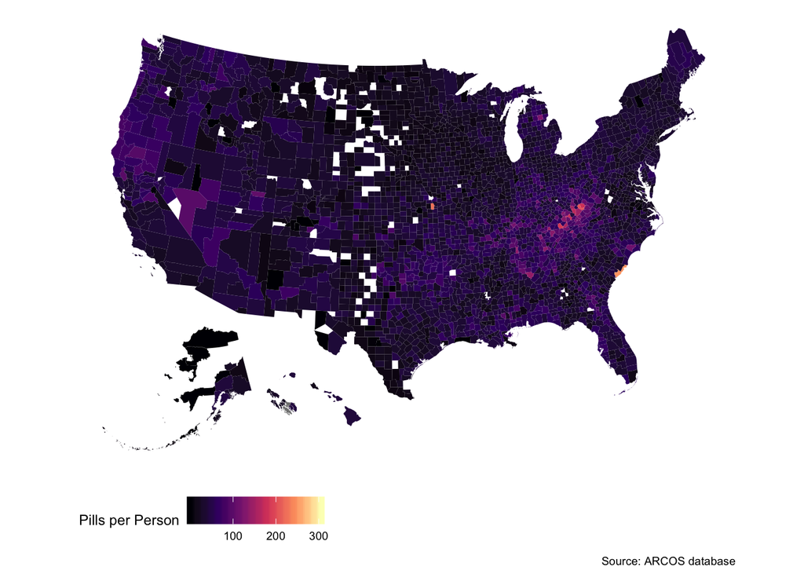

```r
arcos_county_geo_data <- county_geodata_shifted %>%
  inner_join(arcos_county_pills_and_population, by=c("GEOID" = "countyfips"))

arcos_county_geo_data %>%
  ggplot(aes(fill = pills_per_person)) +
  geom_sf(lwd = 0) +
  theme_map() +
  labs(fill = 'Pills per Person', caption = "Source: ARCOS database") +
  theme(legend.position = "bottom") +
  scale_fill_viridis_c(option = "magma",labels = comma)
```

Overdose rate This map shows the data for overdose rates for counties across America. There are many counties that lack sufficient data, which is why there are a lot of white spaces. The darker areas have lower rates of overdoses and the lighter areas have higher rates of overdoses.

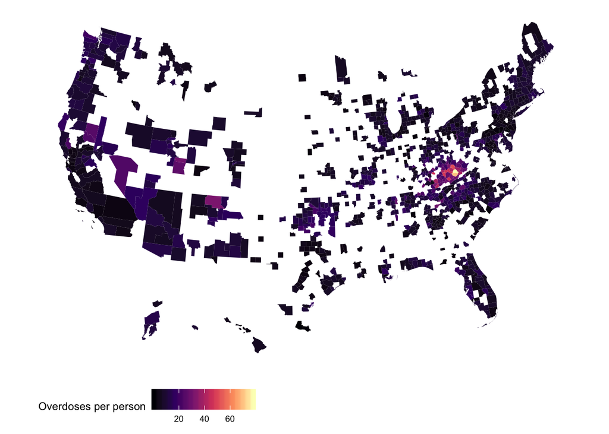

```r
overdose_urban_rural_geo <- county_geodata_shifted  %>%
  inner_join(overdose_urban_rural_combined, by=c("GEOID" = "County Code"))

overdose_urban_rural_geo %>%
  ggplot(aes(fill = `Crude Rate`)) +
  geom_sf(lwd = 0) +
  theme_map() +
  labs(fill = 'Overdoses per person') +
  theme(legend.position = "bottom") +
  scale_fill_viridis_c(option = "magma",labels = comma)
```

Racial Makeup This map shows the percent of white populations across America. The lighter colors show higher rates of white populations, the darker colors show higher rates of nonwhite population.

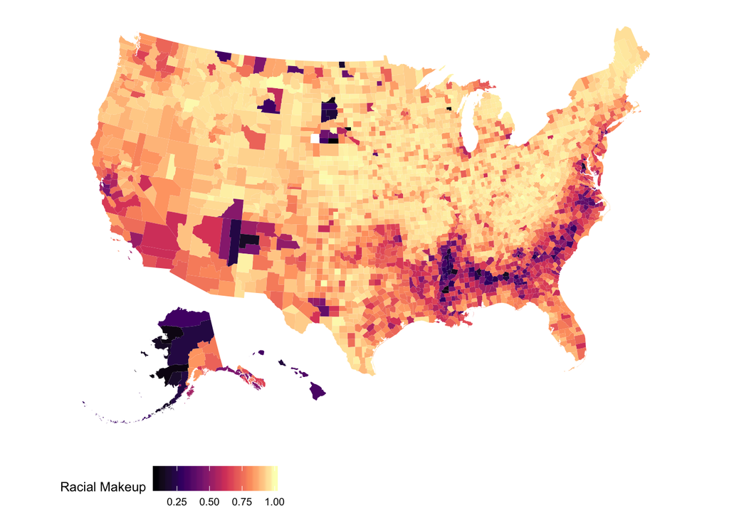

```r
racial_makeup_geo <- county_geodata_shifted %>%
  inner_join(racial_makeup, by='GEOID')

racial_makeup_geo %>%
  ggplot(aes(fill = pct_white)) +
  geom_sf(lwd = 0) +
  theme_map() +
  labs(fill = 'Racial Makeup') +
  theme(legend.position = "bottom") +
  scale_fill_viridis_c(option = "magma",labels = comma)
```

Income This map shows the average income for counties across the United States. Darker colors show lower average incomes and lighter colors show higher average incomes.

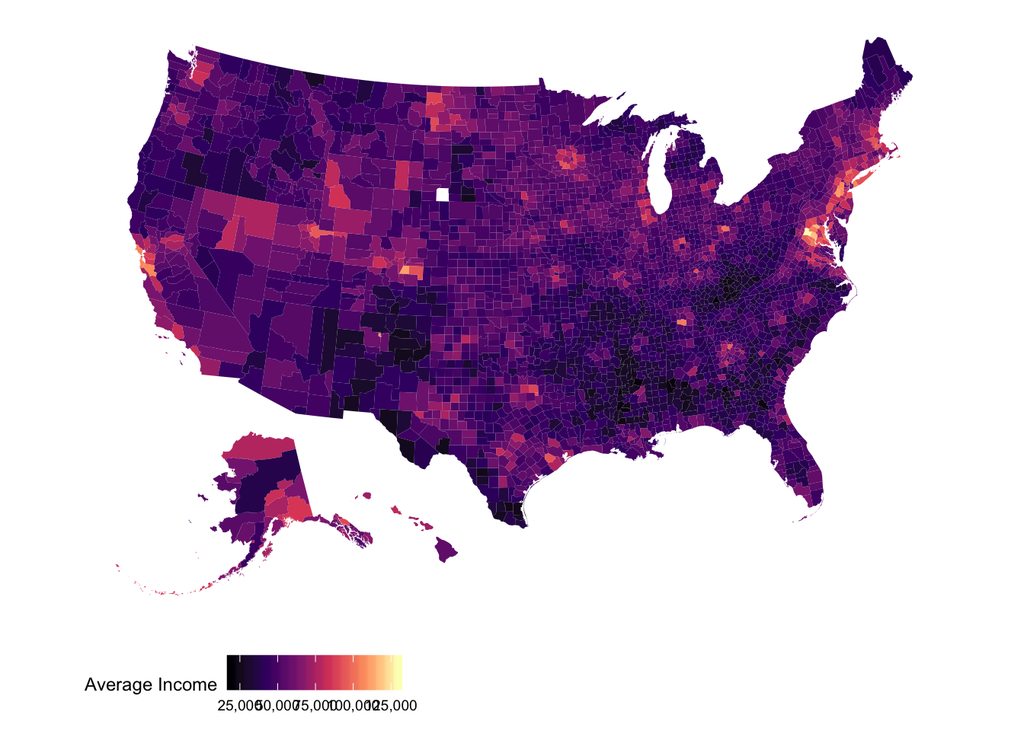

```r
county_income_geo <- county_geodata_shifted %>%
  inner_join(county_income, by='GEOID')

county_income_geo %>%
  ggplot(aes(fill = estimate.y)) +
  geom_sf(lwd = 0) +
  theme_map() +
  labs(fill = 'Average Income') +
  theme(legend.position = "bottom") +
  scale_fill_viridis_c(option = "magma",labels = comma)
```

#of the counties classified 5 and 7, which counties had significantly high pills for the population? This scatter plot maps the total pills and total population for counties classified as 5 and 7 on the RUCC. It shows that there is a strong correlation between population and pills shipped, but it also shows a few specific outliers.

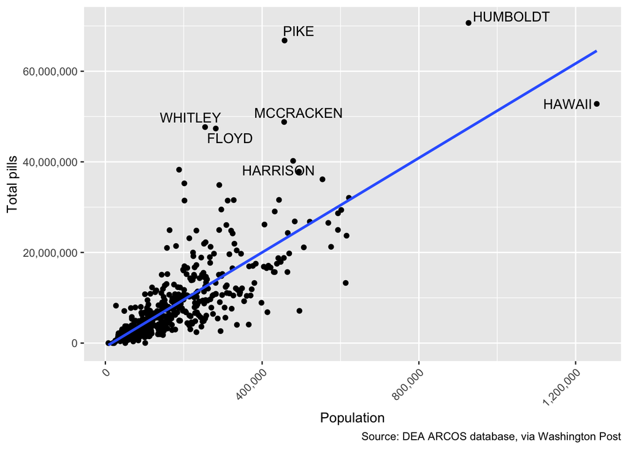

```r
five_seven <- arcos_county_pills_and_population %>%
  filter(RUCC_2013 == 5 | RUCC_2013 == 7) %>%
  arrange(desc(buyer_state))

ggplot(five_seven) +
  geom_point(aes(total_population, total_pills)) +
  labs(x="Population", y="Total pills", caption = "Source: DEA ARCOS database, via Washington Post", fill="buyer_county") +
  scale_y_continuous(labels = comma) +
  scale_x_continuous(labels = comma) +
  theme(axis.text.x = element_text(angle = 45, hjust = 1)) +
  geom_smooth(aes(total_population, total_pills), method = "lm", se = FALSE) +
  geom_text_repel(aes(total_population, total_pills, label=buyer_county),
                  subset(five_seven, total_pills > 40000000))
```